# Which rivers to include?

Jóhannes Guðbrandsson

2025-03-11

```r
source("veidi.R")
library(leaflet)
```

# 1 Disclamers

- We don’t distinguish between 0 salmon catch and no report. This will inflate the mean for rivers with sporadic salmon catches.
- We are not using information on river closed to fishing (protected rivers)

# 2 Rivers close to 40-50 cutoff

## 2.1 In 2020 assessment. 10 year mean higher than 40 and lower than 50

```r
ahaetta |>
  filter(expMedal10< 50 & expMedal10 > 40, ath!="ny") |>
  kableExtra::kbl(digits = 2) |>
  kableExtra::kable_styling("striped", full_width = F)
```

| adal_nr | adalvatnsfall | landsvaedi | landsvaedi_id | M | hraMedal | logMedal | expMedal | M10 | hraMedal10 | logMedal10 | expMedal10 | N_ar | nafn | V | N | fjarlægð | Meðalfjöldi | fjoldi.flokk | ATH | ath | vatnsfall_id | vatnsfall |
| --- | --- | --- | --- | --- | --- | --- | --- | --- | --- | --- | --- | --- | --- | --- | --- | --- | --- | --- | --- | --- | --- | --- |
| 410 | Eldvatn | Suðurland | 7 | 220 | 44.78 | 3.41 | 30.27 | 111.28 | 48.19 | 3.75 | 42.48 | 49 | Eldvatn í Meðallandi | -17.95 | 63.6 | NA | 43 | 5 | NA |  | 528 659 679 1740 1954 | Eldvatn Allt svæðið Eldvatn Eldvatn Botnar Eldvatn Meðallandi Skálmarbær Tjörn Steinsmýrarvötn |
| 716 | Gljúfurá | Norðurland vestra | 4 | 298 | 108.83 | 4.32 | 75.48 | 176.72 | 57.65 | 3.79 | 44.36 | 35 | Gljúfurá | -20.47 | 65.5 | 450 | 168 | 5 | NA |  | 879 | Gljúfurá - Húnaþing Öll svæði Gljúfurá Húnaþingi |

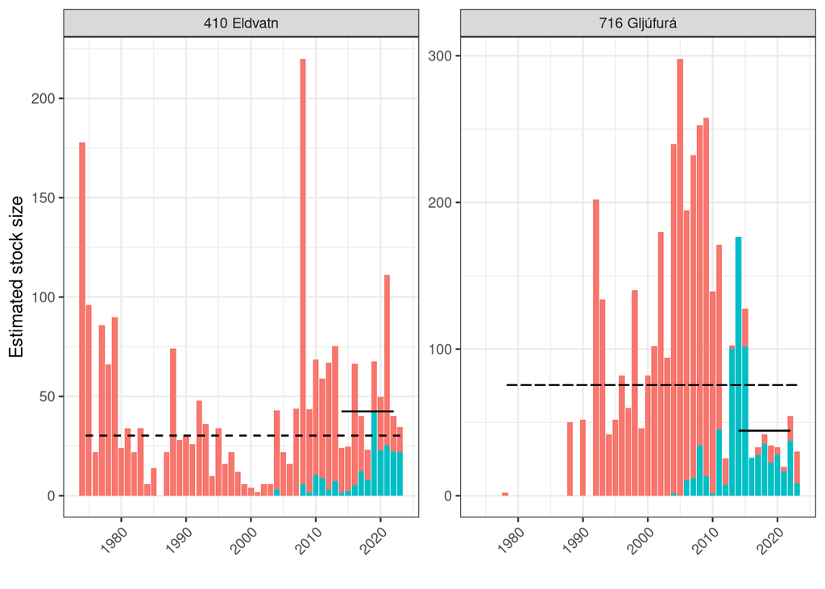

```r
stofnmat |>
  filter(adal_nr %in% ahaetta$adal_nr[ahaetta$expMedal10< 50 & ahaetta$expMedal10 > 40 & ahaetta$ath!="ny"]) |>
  mutate(expMedal10 = ifelse(ar<2014,NA,expMedal10)) |>
  #filter(expMedal10<100) |>
  pivot_longer(starts_with("stofn_tmp"),names_to = "sleppt_kodi", values_to = "stofn_tmp", names_prefix = "stofn_tmp_") |>
  #filter(!(adal_nr %in% c("Bjarnafjarðará"=152))) |>
  ggplot(aes(ar,stofn_tmp, fill=factor(sleppt_kodi))) +
  geom_bar(stat = "identity")+
  geom_path(aes(y=expMedal10), col="black") +
  geom_path(aes(y=expMedal), col="black", linetype = 2) +
  facet_wrap(~paste(adal_nr,adalvatnsfall), scales = "free_y") +
  xlab("") +
  ylab("Estimated stock size") +
  theme(axis.text.x=element_text(angle=45, hjust=1)) +
  theme(legend.position = "none")
```

```r
ahaetta |>
  filter(expMedal10< 50 & expMedal10 > 40, ath!="ny") |>
  mutate(merki = paste(adal_nr, nafn)) |>
  leaflet() |>
  addTiles() |>
  addLabelOnlyMarkers(lng = ~V, lat = ~N, label = ~merki,
                      labelOptions = labelOptions(noHide = T, textsize = "12px"),
                      clusterOptions = markerClusterOptions())
```

[interactive chart not shown]

## 2.2 In 2020 assessment. 10 year mean lower than 40, longterm mean higher than 40

- Ósá / Setbergsá catch reports not returned in latest years. Records for Stóru Langadalsá returned but not for Setbergsá
- Selá temperature dependent?
- Selfljót / Gilsá. Temperature dependent?
- Vatnsholtsá / Vatnasvæði Lýsu. Mostly trout / charr fishing. Catch and release in latest years

```r
ahaetta |>
  filter(expMedal10< 40 & expMedal > 40, ath!="ny") |>
  kableExtra::kbl(digits = 2) |>
  kableExtra::kable_styling("striped", full_width = F)
```

| adal_nr | adalvatnsfall | landsvaedi | landsvaedi_id | M | hraMedal | logMedal | expMedal | M10 | hraMedal10 | logMedal10 | expMedal10 | N_ar | nafn | V | N | fjarlægð | Meðalfjöldi | fjoldi.flokk | ATH | ath | vatnsfall_id | vatnsfall |
| --- | --- | --- | --- | --- | --- | --- | --- | --- | --- | --- | --- | --- | --- | --- | --- | --- | --- | --- | --- | --- | --- | --- |
| 1898 | Ósá | Vesturland | 2 | 592.0 | 164.24 | 4.62 | 101.40 | 15.68 | 10.14 | 2.19 | 8.95 | 40 | Setbergsá | -22.57 | 65.03 | -311 | 78 | 5 | Ósá. Nánast engin skráning frá 2013 | ut | 522 1881 | Setbergsá - Skógarströnd Allt Stóra Langadalsá Skógarströnd Stóra Langadalsá Setbergsá Stóra-Langadalsá |
| 2063 | Selá | Vestfirðir | 3 | 190.0 | 64.99 | 3.88 | 48.28 | 119.70 | 47.32 | 3.66 | 38.85 | 42 | Selá í Steingrímsfirði | -21.72 | 65.78 | 350 | 68 | 5 | NA | ut | 1059 | Selá Allt svæðið Selá Steingrímsfirði |
| 2097 | Selfljót | Austfirðir | 6 | 241.5 | 81.80 | 4.13 | 62.01 | 86.00 | 38.65 | 3.47 | 32.21 | 37 | Selfljót og Gilsá | -13.99 | 65.60 | 1050 | 117 | 5 | NA | ut | 261 | Selfljót og Gilsá Selfljót og Gilsá Austurland Selfljót og Gilsá |
| 2646 | Vatnsholtsá | Vesturland | 2 | 624.0 | 151.86 | 4.43 | 83.71 | 65.85 | 27.30 | 3.18 | 24.10 | 38 | Vatnsholtsós og vötn | -23.27 | 64.83 | -430 | 97 | 5 | NA | ut | 531 | Vatnsholtsá Vatnsholtsá Vatnasvæði Lýsu |

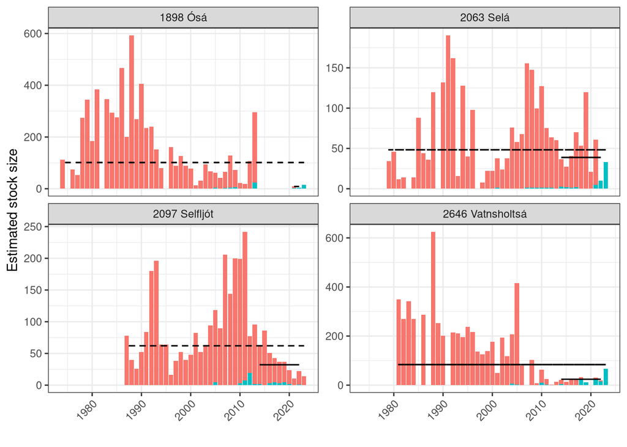

```r
stofnmat |>
  filter(adal_nr %in% ahaetta$adal_nr[ahaetta$expMedal10< 40 & ahaetta$expMedal > 40 & ahaetta$ath!="ny"]) |>
  mutate(expMedal10 = ifelse(ar<2014,NA,expMedal10)) |>
  #filter(expMedal10<100) |>
  pivot_longer(starts_with("stofn_tmp"),names_to = "sleppt_kodi", values_to = "stofn_tmp", names_prefix = "stofn_tmp_") |>
  #filter(!(adal_nr %in% c("Bjarnafjarðará"=152))) |>
  ggplot(aes(ar,stofn_tmp, fill=factor(sleppt_kodi))) +
  geom_bar(stat = "identity")+
  geom_path(aes(y=expMedal10), col="black") +
  geom_path(aes(y=expMedal), col="black", linetype = 2) +
  facet_wrap(~paste(adal_nr,adalvatnsfall), scales = "free_y") +
  xlab("") +
  ylab("Estimated stock size") +
  theme(axis.text.x=element_text(angle=45, hjust=1)) +
  theme(legend.position = "none")
```

```r
ahaetta |>
  filter(expMedal10< 40 & expMedal > 40, ath!="ny") |>
  mutate(merki = paste(adal_nr, nafn)) |>
  leaflet() |>
  addTiles() |>
  addLabelOnlyMarkers(lng = ~V, lat = ~N, label = ~merki,
                      labelOptions = labelOptions(noHide = T, textsize = "12px"),
                      clusterOptions = markerClusterOptions())
```

[interactive chart not shown]

## 2.3 Not in 2020 assessment. 10 year mean lower than 40, longterm mean higher than 40

- Effect of smolt releases
- Most likely a wild stock in Selá

```r
ahaetta |>
  filter(expMedal10< 40 & expMedal > 40 & ath=="ny") |>
  kableExtra::kbl(digits = 2) |>
  kableExtra::kable_styling("striped", full_width = F)
```

| adal_nr | adalvatnsfall | landsvaedi | landsvaedi_id | M | hraMedal | logMedal | expMedal | M10 | hraMedal10 | logMedal10 | expMedal10 | N_ar | nafn | V | N | fjarlægð | Meðalfjöldi | fjoldi.flokk | ATH | ath | vatnsfall_id | vatnsfall |
| --- | --- | --- | --- | --- | --- | --- | --- | --- | --- | --- | --- | --- | --- | --- | --- | --- | --- | --- | --- | --- | --- | --- |
| 618 | Fögruhlíðará | Austfirðir | 6 | 165.0 | 60.84 | 3.69 | 40.03 | 165.0 | 52.12 | 3.32 | 27.75 | 17 | Fögruhlíðará | -14.39 | 65.72 | NA | NA | NA | Fögruhlíðará | ny | 999 1904 | Fögruhlíðará Allt svæðið Fögruhlíðará Fögruhlíðará Héraðsflóa |
| 2090 | Selá | Austfirðir | 6 | 298.5 | 132.16 | 4.42 | 83.05 | 80.5 | 30.17 | 3.17 | 23.74 | 15 | Selá í Álftafirði | -14.50 | 64.53 | NA | NA | NA | Selá í Álftafirði | ny | 984 | Selá Álftafirði Selá Selá |

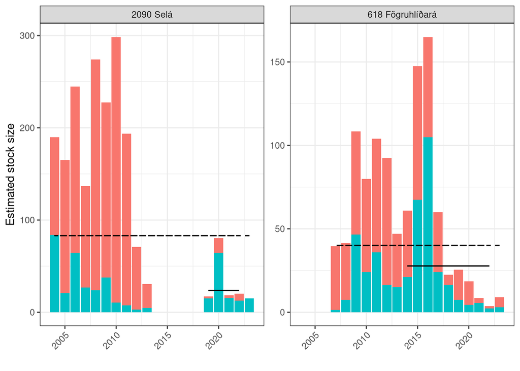

```r
stofnmat |>
  filter(adal_nr %in% ahaetta$adal_nr[ahaetta$expMedal10< 40 & ahaetta$expMedal > 40 & ahaetta$ath=="ny"]) |>
  mutate(expMedal10 = ifelse(ar<2014,NA,expMedal10)) |>
  #filter(expMedal10<100) |>
  pivot_longer(starts_with("stofn_tmp"),names_to = "sleppt_kodi", values_to = "stofn_tmp", names_prefix = "stofn_tmp_") |>
  #filter(!(adal_nr %in% c("Bjarnafjarðará"=152))) |>
  ggplot(aes(ar,stofn_tmp, fill=factor(sleppt_kodi))) +
  geom_bar(stat = "identity")+
  geom_path(aes(y=expMedal10), col="black") +
  geom_path(aes(y=expMedal), col="black", linetype = 2) +
  xlab("") +
  ylab("Estimated stock size") +
  facet_wrap(~paste(adal_nr,adalvatnsfall), scales = "free_y") +
  theme(axis.text.x=element_text(angle=45, hjust=1)) +
  theme(legend.position = "none")
```

```r
ahaetta |>
  filter(expMedal10< 40 & expMedal > 40 & ath=="ny") |>
  mutate(merki = paste(adal_nr, nafn)) |>
  leaflet() |>
  addTiles() |>
  addLabelOnlyMarkers(lng = ~V, lat = ~N, label = ~merki,
                      labelOptions = labelOptions(noHide = T, textsize = "12px"),
                      clusterOptions = markerClusterOptions())
```

[interactive chart not shown]

## 2.4 Not in 2020 assessment. 10 year mean not available, longterm mean higher than 40

- Most of these smolt releases / adult salmon transport
- Móra, Tjarnará, Kiðafellsá, Hoffelssá (Laxá í Nesjum) with wild stock? Stock size?

```r
ahaetta |>
  filter(is.na(expMedal10) & expMedal > 40 & ath=="ny") |>
  kableExtra::kbl(digits = 2) |>
  kableExtra::kable_styling("striped", full_width = F)
```

| adal_nr | adalvatnsfall | landsvaedi | landsvaedi_id | M | hraMedal | logMedal | expMedal | M10 | hraMedal10 | logMedal10 | expMedal10 | N_ar | nafn | V | N | fjarlægð | Meðalfjöldi | fjoldi.flokk | ATH | ath | vatnsfall_id | vatnsfall |
| --- | --- | --- | --- | --- | --- | --- | --- | --- | --- | --- | --- | --- | --- | --- | --- | --- | --- | --- | --- | --- | --- | --- |
| 203 | Botnsá | Vestfirðir | 3 | 1200.0 | 277.87 | 4.51 | 90.51 | NA | NA | NA | NA | 15 | NA | NA | NA | NA | NA | NA | NA | ny | 1919 1963 | Botnsá Súgandafirði Botnslón Súgandafirði |
| 839 | Hafnará | Vesturland | 2 | 652.0 | 338.67 | 5.60 | 271.14 | NA | NA | NA | NA | 6 | NA | NA | NA | NA | NA | NA | NA | ny | 1931 | Hafnará |
| 990 | Hoffellsá | NA | NA | 512.5 | 131.53 | 4.39 | 80.73 | NA | NA | NA | NA | 17 | Hoffellsá | -15.24 | 64.28 | NA | NA | NA | Hoffellsá | ny | 1839 1905 | Hoffellsá Laxá í Nesjum Hornafirði |
| 1028 | Hólmkelsá | NA | NA | 44.0 | 44.00 | 3.78 | 44.00 | NA | NA | NA | NA | 1 | NA | NA | NA | NA | NA | NA | NA | ny | 1880 | Hólmkelsá |
| 1583 | Laxá | NA | NA | 346.0 | 130.67 | 3.98 | 53.72 | NA | NA | NA | NA | 3 | NA | NA | NA | NA | NA | NA | NA | ny | 1888 1960 | Laxá Króksfirði Laxá og Bæjará |
| 1795 | Móra | Vestfirðir | 3 | 90.0 | 67.33 | 4.07 | 58.72 | NA | NA | NA | NA | 6 | NA | NA | NA | NA | NA | NA | NA | ny | 1889 | Móra |
| 1872 | Núpá | Vesturland | 2 | 488.0 | 130.85 | 3.76 | 42.77 | NA | NA | NA | NA | 23 | NA | NA | NA | NA | NA | NA | NA | ny | 1924 | Núpá Hafursfirði |
| 1894 | Ósá | Vestfirðir | 3 | 194.0 | 103.50 | 4.44 | 84.78 | NA | NA | NA | NA | 4 | NA | NA | NA | NA | NA | NA | NA | ny | 1890 1959 | Ósá Veiðifélag Bolungarvíkur |
| 2233 | Skorravíkurá | NA | NA | 76.0 | 73.00 | 4.29 | 72.94 | NA | NA | NA | NA | 2 | NA | NA | NA | NA | NA | NA | NA | ny | 1886 | Skorravíkurá |
| 2510 | Tjarnará | Norðurland vestra | 4 | 186.0 | 87.65 | 4.31 | 74.77 | NA | NA | NA | NA | 30 | NA | NA | NA | NA | NA | NA | NA | ny | 1749 | Tjarnará |
| 2962 | Örlygsstaðaá | Vesturland | 2 | 134.0 | 98.30 | 4.48 | 88.53 | NA | NA | NA | NA | 5 | NA | NA | NA | NA | NA | NA | NA | ny | 1930 | Örlygstaðaá |
| 3020 | Kiðafellsá | Reykjanes | 1 | 120.0 | 52.57 | 3.73 | 41.80 | NA | NA | NA | NA | 7 | NA | NA | NA | NA | NA | NA | NA | ny | 1964 | Kiðafellsá |

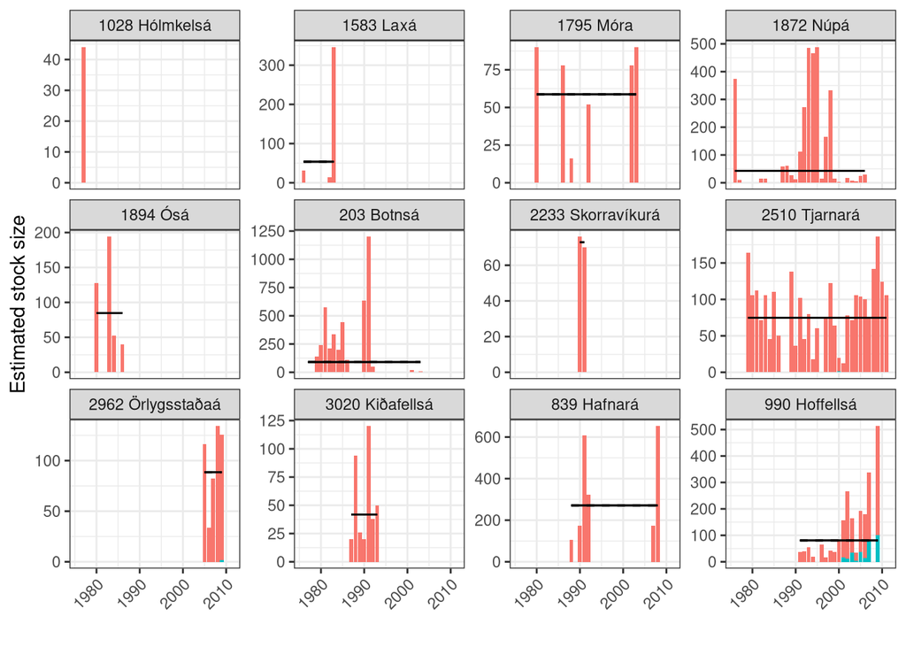

```r
stofnmat |>
  filter(adal_nr %in% ahaetta$adal_nr[is.na(ahaetta$expMedal10) & ahaetta$expMedal > 40 & ahaetta$ath=="ny"]) |>
  #mutate(expMedal10 = ifelse(ar<2014,NA,expMedal10)) |>
  #filter(expMedal10<100) |>
  pivot_longer(starts_with("stofn_tmp"),names_to = "sleppt_kodi", values_to = "stofn_tmp", names_prefix = "stofn_tmp_") |>
  #filter(!(adal_nr %in% c("Bjarnafjarðará"=152))) |>
  ggplot(aes(ar,stofn_tmp, fill=factor(sleppt_kodi))) +
  geom_bar(stat = "identity")+
  geom_path(aes(y=expMedal10), col="black") +
  geom_path(aes(y=expMedal), col="black", linetype = 2) +
  facet_wrap(~paste(adal_nr,adalvatnsfall), scales = "free_y") +
  xlab("") +
  ylab("Estimated stock size") +
  theme(axis.text.x=element_text(angle=45, hjust=1)) +
  theme(legend.position = "none")
```

- Need coordinates

# 3 Not in 2020 assessment. 10 year over 50

- Smolt releases / ranching. Shoud be in the model, but will not affect production if they go over 4% intrusion
  - Affal, Skógá, Lagarfljót, (Jökla?)
- New stocks. Fish ladders and hydropower
  - Svínafossá, (Jökla?)
- Kúðafljót as Tungufljót in 2020 assessment
- Skaftá as Geirlandsá in 2020 assessment
- Don’t know why the rest were not in the 2020 assessment
  - Staðará Súgandafirði only 7 years of records, Lagarfljót 9 years

```r
ahaetta |>
  filter(expMedal10 >= 50, ath=="ny") |>
  kableExtra::kbl(digits = 2) |>
  kableExtra::kable_styling("striped", full_width = F)
```

| adal_nr | adalvatnsfall | landsvaedi | landsvaedi_id | M | hraMedal | logMedal | expMedal | M10 | hraMedal10 | logMedal10 | expMedal10 | N_ar | nafn | V | N | fjarlægð | Meðalfjöldi | fjoldi.flokk | ATH | ath | vatnsfall_id | vatnsfall |
| --- | --- | --- | --- | --- | --- | --- | --- | --- | --- | --- | --- | --- | --- | --- | --- | --- | --- | --- | --- | --- | --- | --- |
| 3 | Affall | Hafbeitarár | 8 | 2465.71 | 833.80 | 5.93 | 374.90 | 2465.71 | 808.37 | 6.05 | 422.32 | 16 | Affall | -20.38 | 63.61 | NA | NA | NA | Affall | ny | 1379 | Affall Affall Affallið |
| 701 | Glerá | Vesturland | 2 | 170.00 | 85.33 | 4.26 | 70.70 | 112.67 | 62.82 | 3.98 | 53.73 | 32 | Glerá í Dölum | -21.74 | 65.20 | NA | NA | NA | Glerá í Dölum | ny | 486 1885 | Glerá Glerá Hvammsfirði |
| 1147 | Hvalsá | Vestfirðir | 3 | 127.18 | 62.56 | 3.96 | 52.40 | 127.18 | 71.47 | 4.11 | 60.86 | 13 | Hvalsá | -21.19 | 65.38 | NA | NA | NA | Hvalsá | ny | 1699 1803 | Hvalsá Hvalsá Kollafirði |
| 1290 | Jökulsá á Dal | Austfirðir | 6 | 1386.00 | 664.80 | 6.14 | 463.04 | 1386.00 | 828.34 | 6.67 | 785.38 | 18 | Jökulsá á Dal | -14.27 | 65.66 | NA | NA | NA | Jökulsá á Dal | ny | 1019 1040 1860 1861 1874 | Jökulsá á Dal Allt svæðið Jökulsá á Dal Jökla I Jökulsá á Dal Jökulsá á Dal II Kaldá Laxá Jökulsárhlíð Vatnasvæði Jöklu |
| 1485 | Kúðafljót | Suðurland | 7 | 468.24 | 146.22 | 4.47 | 87.63 | 468.24 | 293.59 | 5.54 | 254.32 | 24 | Kúðafljót | -18.18 | 63.46 | NA | NA | NA | Kúðafljót | ny | 527 1907 | Kúðafljót og hliðarár Tungufljót Tungufljót Allt svæðið |
| 1516 | Lagarfljót | Austfirðir | 6 | 388.00 | 77.11 | 3.09 | 21.94 | 388.00 | 185.33 | 4.93 | 137.72 | 9 | Lagarfljót | -14.27 | 65.67 | NA | NA | NA | Lagarfljót | ny | 1739 1779 | Kelduá Lagarfljót |
| 1592 | Laxá | Norðurland vestra | 4 | 490.00 | 175.21 | 4.76 | 116.80 | 246.50 | 129.64 | 4.50 | 89.77 | 32 | Laxá á Skaga | -19.85 | 65.90 | NA | NA | NA | Laxá á Skaga | ny | 1772 | Laxá á Skaga Laxá Laxá Laxárdal Skefilstaðahreppi |
| 2164 | Skaftá eystri grein | Suðurland | 7 | 793.50 | 156.21 | 4.80 | 122.02 | 288.21 | 136.05 | 4.84 | 126.38 | 50 | Skaftá | -17.79 | 63.66 | NA | NA | NA | Skaftá | ny | 494 639 801 1079 1100 1741 1908 1909 1945 | Geirlandsá Geirlandsá Grenlækur Svæði 5 - Seglbúðir Hörgsá á Síðu Hörgsá Tungulækur Allt svæðið Geirlandsá Grenlækur Hellisá Holtsá Hörgsá Hörgárdal Hörgsá Síðu Jónskvísl og Sýrlækur Skaftá Tungulækur |
| 2239 | Skógá | Hafbeitarár | 8 | 3061.00 | 454.83 | 4.97 | 144.06 | 226.79 | 115.77 | 4.38 | 79.89 | 21 | Skógá | -19.57 | 63.49 | NA | NA | NA | Skógá | ny | 1479 | Skógá Skógá Skógá Rángárvallasýsla |
| 2281 | Staðará | Vestfirðir | 3 | 185.26 | 103.11 | 4.43 | 84.18 | 185.26 | 185.26 | 5.22 | 185.26 | 7 | Staðará í Súgandafirði | -23.57 | 66.12 | NA | NA | NA | Staðará í Súgandafirði | ny | 784 | Staðar- og Vatnadalsá |
| 2282 | Staðará | Vestfirðir | 3 | 417.89 | 165.67 | 4.94 | 139.20 | 417.89 | 214.59 | 5.24 | 189.58 | 43 | Staðará í Steingrímsfirði | -21.78 | 65.77 | NA | NA | NA | Staðará í Steingrímsfirði | ny | 181 | Staðará Allt Svæðið Staðará Steingrímsf |
| 2452 | Svínafossá | Vesturland | 2 | 415.50 | 139.86 | 4.49 | 89.48 | 402.31 | 161.40 | 4.91 | 135.97 | 23 | Svínafossá | -22.21 | 65.03 | NA | NA | NA | Svínafossá | ny | 482 | Svínafossá |
| 2643 | Vatnsdalsá | Vestfirðir | 3 | 201.74 | 108.54 | 4.50 | 89.88 | 201.74 | 95.71 | 4.35 | 77.50 | 11 | Vatnsdalsá í Vatnsfirði | -23.13 | 65.59 | NA | NA | NA | Vatnsdalsá í Vatnsfirði | ny | 1359 | Vatnsdalsá í Vatnsfirði Vatnsdalsá Vatnsdalsá |
| 2799 | Þorskafjarðará | Vestfirðir | 3 | 160.50 | 53.70 | 3.64 | 37.93 | 160.50 | 71.36 | 4.09 | 59.63 | 26 | Þorskafjarðará | -22.09 | 65.60 | NA | NA | NA | Þorskafjarðará | ny | 495 | Þorskafjarðará Þorskafjarðará Þorskafjarðará |

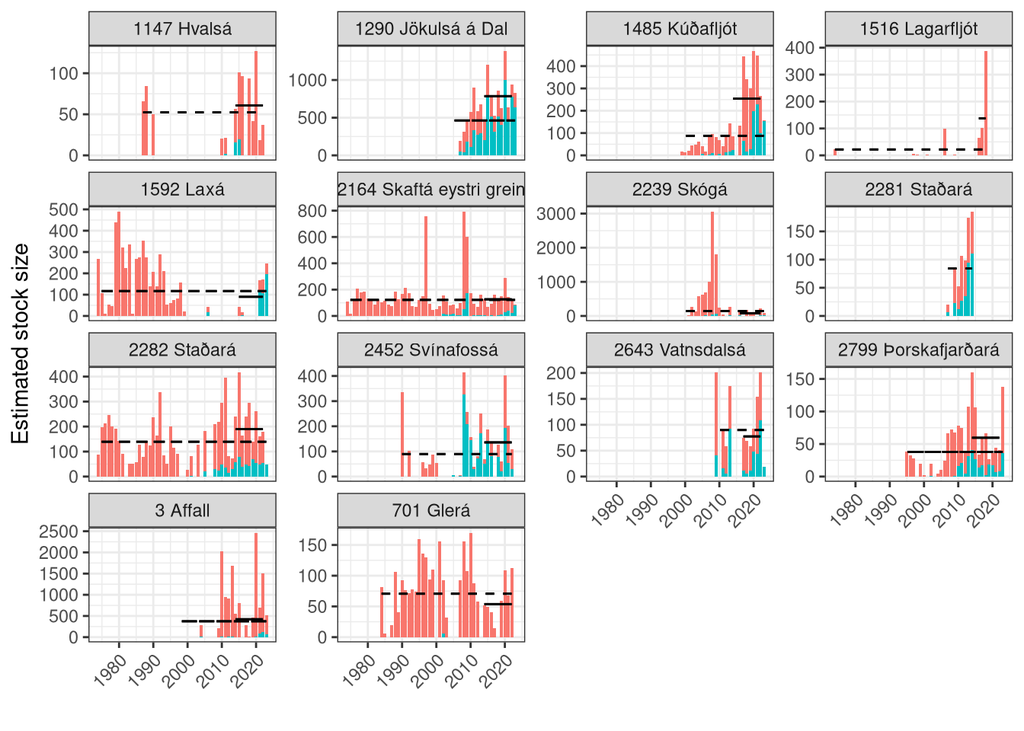

```r
stofnmat |>
  filter(adal_nr %in% ahaetta$adal_nr[ahaetta$expMedal10 >= 50 & ahaetta$ath=="ny"]) |>
  mutate(expMedal10 = ifelse(ar<2014,NA,expMedal10)) |>
  #filter(expMedal10<100) |>
  pivot_longer(starts_with("stofn_tmp"),names_to = "sleppt_kodi", values_to = "stofn_tmp", names_prefix = "stofn_tmp_") |>
  #filter(!(adal_nr %in% c("Bjarnafjarðará"=152))) |>
  ggplot(aes(ar,stofn_tmp, fill=factor(sleppt_kodi))) +
  geom_bar(stat = "identity")+
  geom_path(aes(y=expMedal10), col="black") +
  geom_path(aes(y=expMedal), col="black", linetype = 2) +
  facet_wrap(~paste(adal_nr,adalvatnsfall), scales = "free_y") +
  xlab("") +
  ylab("Estimated stock size") +
  theme(axis.text.x=element_text(angle=45, hjust=1)) +
  theme(legend.position = "none")
```

```r
ahaetta |>
  filter(expMedal10 >= 50, ath=="ny") |>
  mutate(merki = paste(adal_nr, nafn)) |>
  leaflet() |>
  addTiles() |>
  addLabelOnlyMarkers(lng = ~V, lat = ~N, label = ~merki,
                      labelOptions = labelOptions(noHide = T, textsize = "12px"),
                      clusterOptions = markerClusterOptions())
```

[interactive chart not shown]

# 4 In 2020 assessment. 10 year mean lower than 40, longterm mean lower than 40

```r
ahaetta |>
  filter(expMedal10< 40 & expMedal < 40 & ath!="ny") |>
  kableExtra::kbl(digits = 2) |>
  kableExtra::kable_styling("striped", full_width = F)
```

| adal_nr | adalvatnsfall | landsvaedi | landsvaedi_id | M | hraMedal | logMedal | expMedal | M10 | hraMedal10 | logMedal10 | expMedal10 | N_ar | nafn | V | N | fjarlægð | Meðalfjöldi | fjoldi.flokk | ATH | ath | vatnsfall_id | vatnsfall |
| --- | --- | --- | --- | --- | --- | --- | --- | --- | --- | --- | --- | --- | --- | --- | --- | --- | --- | --- | --- | --- | --- | --- |
| 423 | Eyjafjarðará | Norðurland eystra | 5 | 142 | 26.43 | 2.75 | 15.58 | 13.00 | 5.51 | 1.52 | 4.58 | 35 | Eyjafjarðará | -18.06 | 65.64 | 691 | 13 | 5 | NA | ut | 787 | Eyjafjarðará Eyjafjarðará Svæði 0-5 |
| 1096 | Hrolleifsdalsá | Norðurland vestra | 4 | 130 | 26.20 | 2.80 | 16.49 | 46.17 | 13.20 | 2.08 | 7.97 | 47 | Hrolleifsdalsá | -19.41 | 66.02 | 594 | 19 | 5 | NA | ut | 981 | Hrolleifsdalsá Hrolleifsdalsá Hrolleifsdalsá |

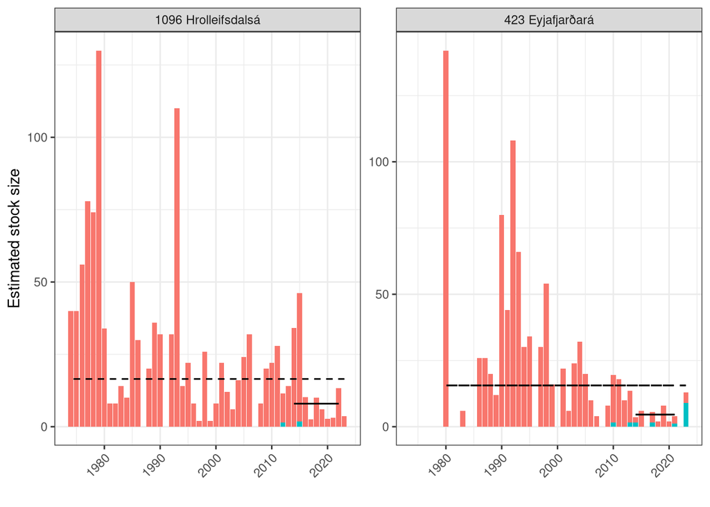

```r
stofnmat |>
  filter(adal_nr %in% ahaetta$adal_nr[ahaetta$expMedal10< 40 & ahaetta$expMedal < 40 & ahaetta$ath!="ny"]) |>
  mutate(expMedal10 = ifelse(ar<2014,NA,expMedal10)) |>
  #filter(expMedal10<100) |>
  pivot_longer(starts_with("stofn_tmp"),names_to = "sleppt_kodi", values_to = "stofn_tmp", names_prefix = "stofn_tmp_") |>
  #filter(!(adal_nr %in% c("Bjarnafjarðará"=152))) |>
  ggplot(aes(ar,stofn_tmp, fill=factor(sleppt_kodi))) +
  geom_bar(stat = "identity")+
  geom_path(aes(y=expMedal10), col="black") +
  geom_path(aes(y=expMedal), col="black", linetype = 2) +
  facet_wrap(~paste(adal_nr,adalvatnsfall), scales = "free_y") +
  xlab("") +
  ylab("Estimated stock size") +
  theme(axis.text.x=element_text(angle=45, hjust=1)) +
  theme(legend.position = "none")
```

```r
ahaetta |>
  filter(expMedal10< 40 & expMedal < 40 & ath!="ny") |>
  mutate(merki = paste(adal_nr, nafn)) |>
  leaflet() |>
  addTiles() |>
  addLabelOnlyMarkers(lng = ~V, lat = ~N, label = ~merki,
                      labelOptions = labelOptions(noHide = T, textsize = "12px"),
                      clusterOptions = markerClusterOptions())
```

[interactive chart not shown]

# 5 Not in 2020 assessment. 10 year mean lower than 40, longterm mean lower than 40

- Some database errors in the 80’s need to be checked

```r
ahaetta |>
  filter(expMedal10<40 & expMedal < 40 & ath=="ny") |>
  kableExtra::kbl(digits = 2) |>
  kableExtra::kable_styling("striped", full_width = F)
```

| adal_nr | adalvatnsfall | landsvaedi | landsvaedi_id | M | hraMedal | logMedal | expMedal | M10 | hraMedal10 | logMedal10 | expMedal10 | N_ar | nafn | V | N | fjarlægð | Meðalfjöldi | fjoldi.flokk | ATH | ath | vatnsfall_id | vatnsfall |
| --- | --- | --- | --- | --- | --- | --- | --- | --- | --- | --- | --- | --- | --- | --- | --- | --- | --- | --- | --- | --- | --- | --- |
| 76 | Ártúnsá | Reykjanes | 1 | 104.00 | 30.22 | 3.16 | 23.57 | 37.41 | 22.63 | 2.97 | 19.56 | 14 | NA | NA | NA | NA | NA | NA | NA | ny | 621 1935 | Ártúnsá Blikdalsá |
| 92 | Bakkaá | Norðurland eystra | 5 | 70.00 | 37.95 | 3.55 | 34.73 | 17.50 | 17.50 | 2.86 | 17.50 | 10 | NA | NA | NA | NA | NA | NA | NA | ny | 1901 1902 1949 | Bakkaá Allt svæðið Bakkaá Bakkafirði Gæsagilsá Veiðifélag Sandvíkur |
| 152 | Bjarnarfjarðará | Vestfirðir | 3 | 12.00 | 5.83 | 1.60 | 4.97 | 7.33 | 4.98 | 1.48 | 4.39 | 12 | NA | NA | NA | NA | NA | NA | NA | ny | 1519 | Bjarnarfjarðará Bjarnarfirði Bjarnarfjarðará Goðdalsá |
| 322 | Dalsá | Norðurland eystra | 5 | 1.47 | 1.47 | 0.39 | 1.47 | 1.47 | 1.47 | 0.39 | 1.47 | 1 | NA | NA | NA | NA | NA | NA | NA | ny | 2079 | Dalsá Flateyjardal |
| 329 | Dalsá | Austfirðir | 6 | 46.00 | 11.50 | 2.00 | 7.38 | 12.00 | 5.70 | 1.55 | 4.72 | 11 | NA | NA | NA | NA | NA | NA | NA | ny | 782 | Dalsá Fáskrúðsfirði |
| 509 | Fjarðará | Austfirðir | 6 | 124.00 | 43.85 | 3.29 | 26.97 | 29.50 | 13.24 | 2.32 | 10.14 | 17 | NA | NA | NA | NA | NA | NA | NA | ny | 201 | Fjarðará Neðra svæði - Efra svæði Fjarðará/Þverá Borgarf.eystri |
| 510 | Fjarðará | Austfirðir | 6 | 114.00 | 28.38 | 2.75 | 15.70 | 15.00 | 9.33 | 2.15 | 8.59 | 28 | NA | NA | NA | NA | NA | NA | NA | ny | 432 | Fjarðará Loðmundarfirði |
| 511 | Fjarðará | Austfirðir | 6 | 310.00 | 25.39 | 2.54 | 12.67 | 45.50 | 13.89 | 2.39 | 10.88 | 31 | NA | NA | NA | NA | NA | NA | NA | ny | 1039 2139 | Fjarðará Fjarðará - Seyðisfyrði Fjarðará Seyðisfirði Seyðisfjarðará |
| 820 | Gufudalsá | Vestfirðir | 3 | 92.00 | 37.22 | 3.32 | 27.71 | 61.47 | 37.13 | 3.51 | 33.39 | 19 | NA | NA | NA | NA | NA | NA | NA | ny | 1539 | Gufudalsá Gufudalsá Gufudalsá |
| 872 | Hamarsá | Norðurland vestra | 4 | 110.00 | 33.02 | 3.21 | 24.75 | 50.85 | 28.18 | 3.12 | 22.57 | 25 | NA | NA | NA | NA | NA | NA | NA | ny | 1141 | Hamarsá |
| 1217 | Hölkná | Austfirðir | 6 | 111.50 | 45.05 | 3.54 | 34.52 | 74.50 | 36.67 | 3.33 | 27.99 | 15 | NA | NA | NA | NA | NA | NA | NA | ny | 1062 | Hölkná Allt svæðið Hölkná í Bakkafirði |
| 1222 | Hörgá | Norðurland eystra | 5 | 34.00 | 5.89 | 1.35 | 3.84 | 2.00 | 1.75 | 0.55 | 1.73 | 23 | NA | NA | NA | NA | NA | NA | NA | ny | 1061 | Hörgá |
| 1291 | Jökulsá á Fjöllum | Norðurland eystra | 5 | 6.00 | 3.64 | 1.19 | 3.28 | 4.50 | 2.66 | 0.85 | 2.35 | 23 | NA | NA | NA | NA | NA | NA | NA | ny | 983 | Brunná |
| 1430 | Kolka | Norðurland vestra | 4 | 149.50 | 46.33 | 3.46 | 31.87 | 105.01 | 31.99 | 3.04 | 20.89 | 27 | NA | NA | NA | NA | NA | NA | NA | ny | 491 1819 | Hjaltadalsá Kolka Kolka Kolka |
| 1609 | Leirá | Vesturland | 2 | 232.00 | 55.54 | 3.63 | 37.61 | 60.63 | 33.47 | 3.35 | 28.64 | 31 | NA | NA | NA | NA | NA | NA | NA | ny | 221 | Leirá Leirá Leirá |
| 1644 | Litliós | Norðurland eystra | 5 | 3.00 | 3.00 | 1.10 | 3.00 | 3.00 | 3.00 | 1.10 | 3.00 | 1 | NA | NA | NA | NA | NA | NA | NA | ny | 2099 | Sauðanesvatn |
| 1676 | Markarfljót | Suðurland | 7 | 20.00 | 12.63 | 2.42 | 11.28 | 15.71 | 9.34 | 1.92 | 6.82 | 9 | NA | NA | NA | NA | NA | NA | NA | ny | 1102 1639 1640 | Álar Markarfljót Markarfljót, Álar og Bakki |
| 1726 | Miðdalsá | Vestfirðir | 3 | 46.95 | 18.15 | 2.29 | 9.92 | 46.95 | 23.70 | 2.92 | 18.62 | 4 | NA | NA | NA | NA | NA | NA | NA | ny | 1659 1894 | Miðdalsá Miðdalsá Steingrímsfirði |
| 1841 | Nesá | NA | NA | 2.86 | 2.86 | 1.05 | 2.86 | 2.86 | 2.86 | 1.05 | 2.86 | 1 | NA | NA | NA | NA | NA | NA | NA | ny |  | Mallandsvötn Skagaheiði Rangatjarnir Mallandsvötn Skagaheiði Selvatn |
| 1858 | Norðfjarðará | Austfirðir | 6 | 72.00 | 32.17 | 3.23 | 25.17 | 42.00 | 17.89 | 2.71 | 15.10 | 20 | NA | NA | NA | NA | NA | NA | NA | ny | 241 | Norðfjarðará Norðfjarðará Allt Svæðið |
| 1878 | Núpsvötn | Suðurland | 7 | 20.00 | 6.45 | 1.57 | 4.78 | 8.90 | 3.89 | 1.19 | 3.27 | 19 | NA | NA | NA | NA | NA | NA | NA | ny | 622 1840 1906 1946 | Brúará Fljótshverfi Laxá Fljótshverfi Laxá Síðu Laxá-Brúará |
| 1893 | Ólafsfjarðará | Norðurland eystra | 5 | 2358.00 | 395.25 | 2.06 | 7.81 | 4.00 | 2.38 | 0.79 | 2.21 | 6 | NA | NA | NA | NA | NA | NA | NA | ny | 1599 1962 | Fjarðará Allt svæðið Fjarðará Ólafsfirði Ólafsfjarðarvatn |
| 2028 | Sauðanesós | Norðurland eystra | 5 | 4.50 | 2.33 | 0.77 | 2.16 | 4.50 | 2.21 | 0.70 | 2.02 | 10 | NA | NA | NA | NA | NA | NA | NA | ny | 1199 | Lónsá Lónsá Allt svæðið |
| 2061 | Selá | Vestfirðir | 3 | 16.00 | 9.20 | 2.02 | 7.57 | 14.66 | 7.49 | 1.84 | 6.28 | 5 | NA | NA | NA | NA | NA | NA | NA | ny | 1869 | Selá Ármúli I og II NET Selá Skjaldfönn Selá Ísafjarðardjúpi |
| 2201 | Skálmardalsá | Vestfirðir | 3 | 24.00 | 8.30 | 1.80 | 6.05 | 14.03 | 7.37 | 1.79 | 6.01 | 21 | NA | NA | NA | NA | NA | NA | NA | ny | 1159 | Skálmardalsá Skálmardalsá öll áin |
| 2241 | Skrauma | Vesturland | 2 | 74.00 | 29.38 | 3.18 | 24.04 | 33.67 | 23.89 | 3.08 | 21.80 | 10 | NA | NA | NA | NA | NA | NA | NA | ny | 1768 | Skrauma |
| 2344 | Stórá | Norðurland eystra | 5 | 612.00 | 34.57 | 2.47 | 11.88 | 14.00 | 5.87 | 1.54 | 4.65 | 44 | NA | NA | NA | NA | NA | NA | NA | ny | 721 722 1763 | Litlaá Allt svæðið Litlaá Kelduhverfi Litluárvötn-Skjálftavatn Skjálftavatn |
| 2408 | Suðurfossá | Vestfirðir | 3 | 194.00 | 53.93 | 3.55 | 34.88 | 98.18 | 48.03 | 3.58 | 36.00 | 32 | NA | NA | NA | NA | NA | NA | NA | ny | 820 | Suðurfossá Suðurfossá Suðurfossá |
| 2425 | Svarfaðardalsá | Norðurland eystra | 5 | 56.00 | 7.19 | 1.36 | 3.89 | 4.00 | 3.50 | 1.24 | 3.46 | 16 | NA | NA | NA | NA | NA | NA | NA | ny | 1600 | Svarfaðardalsá |
| 2581 | Unadalsá | Norðurland vestra | 4 | 2.99 | 2.99 | 1.10 | 2.99 | 2.99 | 2.99 | 1.10 | 2.99 | 1 | NA | NA | NA | NA | NA | NA | NA | ny | 1871 | Unadalsá |
| 2629 | Valshamarsá | Vesturland | 2 | 128.00 | 34.36 | 3.16 | 23.52 | 67.33 | 25.70 | 2.80 | 16.49 | 23 | NA | NA | NA | NA | NA | NA | NA | ny | 619 | Valshamarsá |
| 2751 | Ytri-laxá | Norðurland vestra | 4 | 374.50 | 58.34 | 3.50 | 33.23 | 82.85 | 36.77 | 3.41 | 30.21 | 27 | NA | NA | NA | NA | NA | NA | NA | ny | 620 | Laxá í Nesjum Laxá í Nesjum Laxá í Nesjum |
| 21780 | Hlíðarvatn | Suðurland | 7 | 32.00 | 6.66 | 1.37 | 3.93 | 17.79 | 10.99 | 2.15 | 8.62 | 15 | NA | NA | NA | NA | NA | NA | NA | ny | 493 | Hlíðarvatn Hlíðarvatn Ármenn |

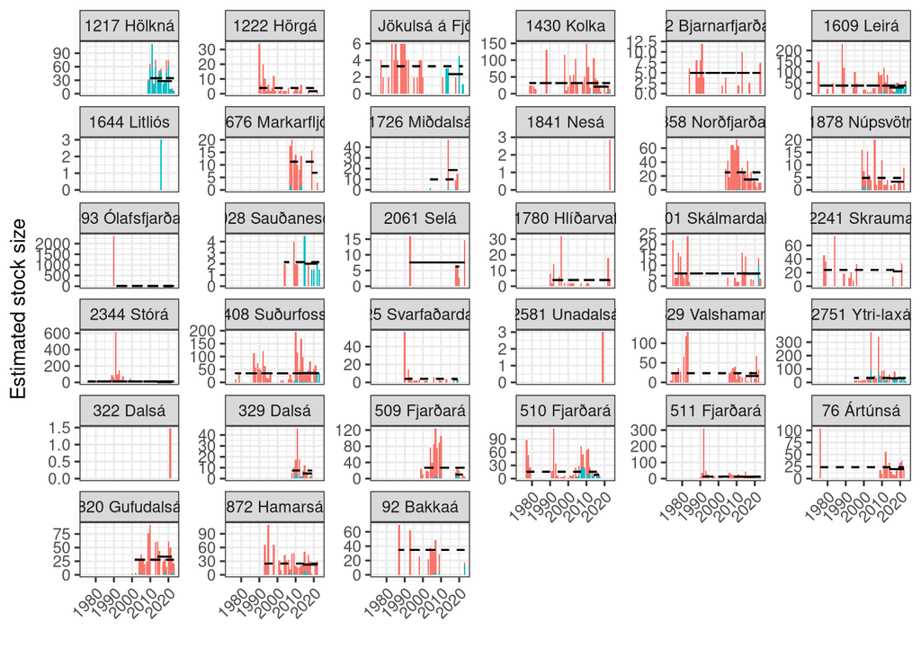

```r
stofnmat |>
  filter(adal_nr %in% ahaetta$adal_nr[ahaetta$expMedal10<40 & ahaetta$expMedal < 40 & ahaetta$ath=="ny"]) |>
  mutate(expMedal10 = ifelse(ar<2014,NA,expMedal10)) |>
  #filter(expMedal10<100) |>
  pivot_longer(starts_with("stofn_tmp"),names_to = "sleppt_kodi", values_to = "stofn_tmp", names_prefix = "stofn_tmp_") |>
  #filter(!(adal_nr %in% c("Bjarnafjarðará"=152))) |>
  ggplot(aes(ar,stofn_tmp, fill=factor(sleppt_kodi))) +
  geom_bar(stat = "identity")+
  geom_path(aes(y=expMedal10), col="black") +
  geom_path(aes(y=expMedal), col="black", linetype = 2) +
  facet_wrap(~paste(adal_nr,adalvatnsfall), scales = "free_y") +
  xlab("") +
  ylab("Estimated stock size") +
  theme(axis.text.x=element_text(angle=45, hjust=1)) +
  theme(legend.position = "none")
```

# 6 Not in 2020 assessment. 10 year mean not available, longterm mean lower than 40

```r
ahaetta |>
  filter(is.na(expMedal10) & expMedal < 40 & ath=="ny") |>
  kableExtra::kbl(digits = 2) |>
  kableExtra::kable_styling("striped", full_width = F)
```

| adal_nr | adalvatnsfall | landsvaedi | landsvaedi_id | M | hraMedal | logMedal | expMedal | M10 | hraMedal10 | logMedal10 | expMedal10 | N_ar | nafn | V | N | fjarlægð | Meðalfjöldi | fjoldi.flokk | ATH | ath | vatnsfall_id | vatnsfall |
| --- | --- | --- | --- | --- | --- | --- | --- | --- | --- | --- | --- | --- | --- | --- | --- | --- | --- | --- | --- | --- | --- | --- |
| 342 | Deildará | Norðurland vestra | 4 | 10.0 | 7.50 | 1.96 | 7.07 | NA | NA | NA | NA | 2 | NA | NA | NA | NA | NA | NA | NA | ny | 1956 | Grafará Höfðaströnd |
| 644 | Geiradalsá | NA | NA | 12.0 | 12.00 | 2.48 | 12.00 | NA | NA | NA | NA | 1 | NA | NA | NA | NA | NA | NA | NA | ny | 1887 | Geiradalsá |
| 661 | Geithellnaá | NA | NA | 6.0 | 6.00 | 1.79 | 6.00 | NA | NA | NA | NA | 1 | NA | NA | NA | NA | NA | NA | NA | ny | 1863 | Geithellnaá |
| 949 | Heydalsá | Vestfirðir | 3 | 6.0 | 6.00 | 1.79 | 6.00 | NA | NA | NA | NA | 1 | NA | NA | NA | NA | NA | NA | NA | ny | 1753 | Heydalsá |
| 1005 | Holtsá | NA | NA | 26.0 | 26.00 | 3.26 | 26.00 | NA | NA | NA | NA | 1 | NA | NA | NA | NA | NA | NA | NA | ny | 1929 | Holtsá Vallnavík Snæf. |
| 1181 | Hverfisfljót | Suðurland | 7 | 8.0 | 4.38 | 1.35 | 3.87 | NA | NA | NA | NA | 4 | NA | NA | NA | NA | NA | NA | NA | ny | 1868 | Eldvatn Siðu |
| 1565 | Langá | Vestfirðir | 3 | 1.5 | 1.50 | 0.41 | 1.50 | NA | NA | NA | NA | 1 | NA | NA | NA | NA | NA | NA | NA | ny | 1979 | Fossá Skutulsfirði |
| 1648 | Ljá | Vesturland | 2 | 18.0 | 13.00 | 2.48 | 12.00 | NA | NA | NA | NA | 2 | NA | NA | NA | NA | NA | NA | NA | ny | 1744 | Ljá |
| 2257 | Sléttuá | Austfirðir | 6 | 18.0 | 7.14 | 1.69 | 5.42 | NA | NA | NA | NA | 7 | NA | NA | NA | NA | NA | NA | NA | ny | 1875 | Sléttuá |
| 2284 | Staðará | Vesturland | 2 | 8.0 | 8.00 | 2.08 | 8.00 | NA | NA | NA | NA | 1 | NA | NA | NA | NA | NA | NA | NA | ny | 1926 | Staðará Staðarsveit |
| 2803 | Þorvaldsdalsá | Norðurland eystra | 5 | 170.0 | 66.40 | 3.26 | 26.07 | NA | NA | NA | NA | 5 | NA | NA | NA | NA | NA | NA | NA | ny | 1896 | Þorvaldsdalsá |

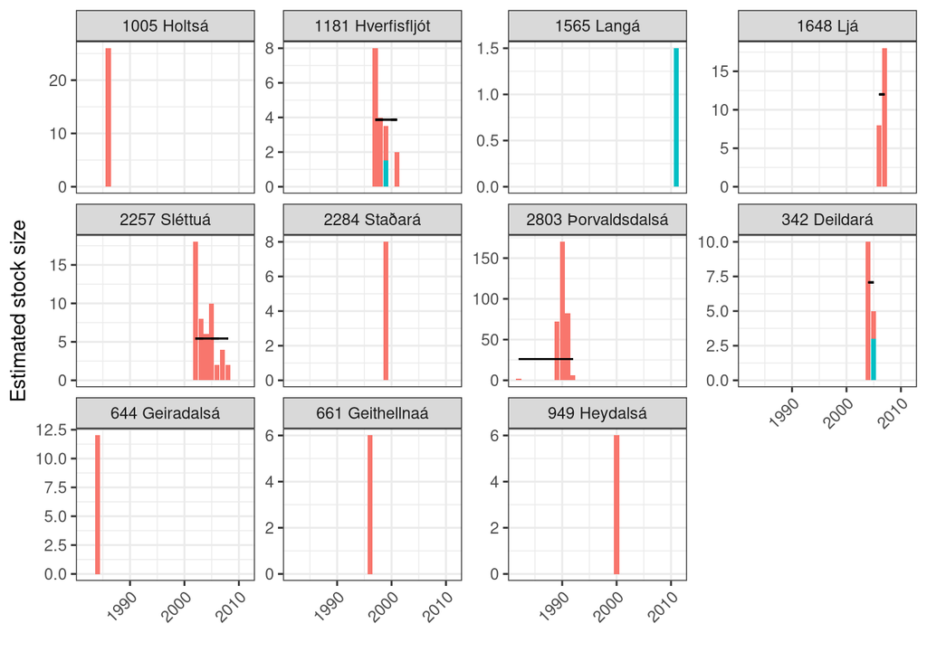

```r
stofnmat |>
  filter(adal_nr %in% ahaetta$adal_nr[is.na(ahaetta$expMedal10) & ahaetta$expMedal < 40 & ahaetta$ath=="ny"]) |>
  #mutate(expMedal10 = ifelse(ar<2014,NA,expMedal10)) |>
  #filter(expMedal10<100) |>
  pivot_longer(starts_with("stofn_tmp"),names_to = "sleppt_kodi", values_to = "stofn_tmp", names_prefix = "stofn_tmp_") |>
  #filter(!(adal_nr %in% c("Bjarnafjarðará"=152))) |>
  ggplot(aes(ar,stofn_tmp, fill=factor(sleppt_kodi))) +
  geom_bar(stat = "identity")+
  geom_path(aes(y=expMedal10), col="black") +
  geom_path(aes(y=expMedal), col="black", linetype = 2) +
  facet_wrap(~paste(adal_nr,adalvatnsfall), scales = "free_y") +
  xlab("") +
  ylab("Estimated stock size") +
  theme(axis.text.x=element_text(angle=45, hjust=1)) +
  theme(legend.position = "none")
```

# 7 In 2020 assessment. 10 year mean over 50

```r
ahaetta |>
  filter(expMedal10>50 & ath!="ny") |>
  kableExtra::kbl(digits = 2) |>
  kableExtra::kable_styling("striped", full_width = F)
```

| adal_nr | adalvatnsfall | landsvaedi | landsvaedi_id | M | hraMedal | logMedal | expMedal | M10 | hraMedal10 | logMedal10 | expMedal10 | N_ar | nafn | V | N | fjarlægð | Meðalfjöldi | fjoldi.flokk | ATH | ath | vatnsfall_id | vatnsfall |
| --- | --- | --- | --- | --- | --- | --- | --- | --- | --- | --- | --- | --- | --- | --- | --- | --- | --- | --- | --- | --- | --- | --- |
| 69 | Álftá | Vesturland | 2 | 1308.00 | 586.11 | 6.31 | 548.29 | 720.95 | 497.29 | 6.16 | 473.15 | 50 | Álftá | -22.23 | 64.58 | -495 | 641 | 10 | NA |  | 485 1922 | Álftá Allt svæðið Álftá á Mýrum Veitá |
| 110 | Baugsstaðaá | Suðurland | 7 | 121.71 | 49.13 | 3.69 | 40.19 | 121.71 | 57.80 | 3.95 | 51.80 | 46 | Vatnas. Baugstaðaós | -20.95 | 63.82 | -722 | 63 | 5 | NA |  | 559 1752 1951 | Baugsstaðaá Hróarholtslækur Hróarsholtslækur Hróarsholtslækur Baugstaðaós Hróarsholtslækur Voli |
| 140 | Bjargaós | Norðurland vestra | 4 | 4162.00 | 2110.87 | 7.57 | 1932.19 | 3092.36 | 1810.52 | 7.46 | 1735.77 | 49 | Víðidalsá og Fitjá | -20.54 | 65.50 | 440 | 2067 | 15 | Bjargaós |  | 101 2179 | Hópið Víðidalsá og Fitjá Víðidalsá Laxasvæði Víðidalsá Silungasvæði |
| 158 | Blanda | Norðurland vestra | 4 | 12166.04 | 2948.58 | 7.81 | 2464.30 | 12166.04 | 4022.73 | 8.03 | 3062.76 | 50 | Blanda | -20.30 | 65.66 | 455 | 3984 | 15 | NA |  | 61 437 1966 | Blanda Allt svæðið Svartá Allt svæðið Blanda Blöndulón Svartá |
| 208 | Botnsá | Reykjanes | 1 | 484.00 | 213.46 | 5.21 | 182.37 | 256.77 | 164.73 | 4.87 | 130.84 | 44 | Botnsá | -21.36 | 64.38 | -568 | 249 | 5 | NA |  | 487 | Botnsá Botnsá Litli-Botn Botnsá Stóri-Botn |
| 225 | Breiðdalsá | Austfirðir | 6 | 2510.50 | 540.53 | 5.76 | 316.48 | 651.50 | 299.83 | 5.43 | 228.96 | 48 | Breiðdalsá | -14.09 | 64.79 | 1190 | 1250 | 15 | NA |  | 859 | Breiðdalsá |
| 257 | Brynjudalsá | Reykjanes | 1 | 1194.00 | 297.56 | 5.46 | 234.03 | 214.90 | 160.48 | 4.99 | 147.10 | 46 | Brynjudalsá | -21.41 | 64.36 | -553 | 347 | 10 | NA |  | 434 | Brynjudalsá Brynjudalsá Hvalfirði Brynjudalsá |
| 277 | Búðardalsá | Vesturland | 2 | 1329.00 | 407.72 | 5.67 | 288.61 | 751.10 | 475.49 | 6.11 | 448.27 | 40 | Búðardalsá | -22.23 | 65.31 | -200 | 679 | 10 | NA |  | 431 | Búðardalsá Búðardalsá á Skarðsströnd Búðardalsá - Allt svæðið |
| 343 | Deildará | Norðurland eystra | 5 | 782.00 | 338.33 | 5.71 | 302.38 | 578.00 | 332.82 | 5.73 | 309.36 | 48 | Deildará | -15.95 | 66.44 | 850 | 371 | 10 | NA |  | 580 | Deildará Deildará á Sléttu Deildará |
| 378 | Dunká (Bakká) | Vesturland | 2 | 620.00 | 226.51 | 5.31 | 202.67 | 418.94 | 232.56 | 5.36 | 213.29 | 47 | Dunká | -21.94 | 65.02 | -289 | 234 | 5 | NA |  | 520 | Dunká Dunká (Bakká) Öll |
| 411 | Elliðaár | Reykjanes | 1 | 4130.00 | 2120.29 | 7.58 | 1959.85 | 1976.60 | 1616.89 | 7.37 | 1579.91 | 50 | Elliðaár | -21.84 | 64.13 | -553 | 1665 | 15 | NA |  | 560 1948 | Elliðaár Allt svæðið Elliðaár Vorveiði Elliðaár Elliðaár Elliðavatn |
| 465 | Fáskrúð | Vesturland | 2 | 979.00 | 460.97 | 6.05 | 424.67 | 722.64 | 440.01 | 6.00 | 402.98 | 46 | Fáskrúð | -21.70 | 65.18 | -265 | 513 | 10 | NA |  | 523 | Fáskrúð |
| 515 | Fjarðarhornsá | Vestfirðir | 3 | 468.15 | 144.13 | 4.06 | 58.05 | 468.15 | 261.18 | 5.47 | 237.36 | 40 | Fjarðarhornsá | -22.55 | 65.65 | -170 | 214 | 5 | NA |  | 1800 1921 | Fjarðarhornsá Fjarðarhornsá Kollafirði Fjarðarhornsá Ísafjarðardjúpi Fjarðarhornsá Kollafirði |
| 531 | Flókadalsá | Norðurland vestra | 4 | 728.00 | 107.19 | 4.08 | 59.38 | 102.58 | 58.24 | 3.97 | 52.85 | 41 | Flókadalsá í Fljótum | -19.15 | 66.04 | 610 | 40 | 5 | NA |  | 740 | Flókadalsá Flókadalsá Neðri hluti |
| 537 | Fnjóská | Norðurland eystra | 5 | 2009.50 | 552.36 | 6.12 | 454.39 | 1020.50 | 443.20 | 5.98 | 395.06 | 49 | Fnjóská | -18.09 | 65.90 | 670 | 824 | 10 | NA |  | 761 1103 | Bakkaá Fnjóskadal Fnjóská Fnjóská Laxasvæði |
| 560 | Fossá | Norðurland vestra | 4 | 221.97 | 76.26 | 4.09 | 59.52 | 221.97 | 155.81 | 5.01 | 150.34 | 46 | Fossá á Skaga | -19.92 | 65.94 | 520 | 64 | 5 | NA |  | 919 | Fossá í Skefilstaðahreppi Fossá öll veiðisvæði |
| 608 | Fróðá | Vesturland | 2 | 468.00 | 152.85 | 4.72 | 111.79 | 207.60 | 151.89 | 4.95 | 140.61 | 43 | Fróðá | -23.62 | 64.89 | -350 | 188 | 5 | NA |  | 430 | Fróðá Fróðá Fróðá |
| 835 | Haffjarðará | Vesturland | 2 | 3430.00 | 1753.57 | 7.40 | 1640.17 | 3025.79 | 2341.32 | 7.73 | 2275.80 | 50 | Haffjarðará | -22.41 | 64.81 | -464 | 2582 | 15 | NA |  | 939 1279 | Haffjarðará Haffjarðará Haffjarðará Hlíðarvatn Mýrum |
| 851 | Hafralónsá | Norðurland eystra | 5 | 1079.50 | 516.47 | 6.11 | 452.04 | 568.00 | 412.51 | 5.98 | 394.80 | 48 | Hafralónsá og Kverká | -15.38 | 66.14 | 860 | 726 | 10 | NA |  | 402 425 | Hafralónsá Kverká Hafralónsá Laxasvæði |
| 867 | Hallá | Norðurland vestra | 4 | 349.00 | 152.24 | 4.86 | 129.46 | 344.05 | 205.62 | 5.27 | 193.87 | 37 | Hallá | -20.28 | 65.78 | 465 | 148 | 5 | NA |  | 959 | Hallá Allt svæðið Hallá Skagaströnd |
| 883 | Haukadalsá | Vesturland | 2 | 2772.00 | 1378.03 | 7.17 | 1294.04 | 2406.98 | 1280.73 | 7.05 | 1157.49 | 50 | Haukadalsá | -21.77 | 65.04 | -278 | 1271 | 15 | NA |  | 759 1917 2279 | Haukadalsá Efri Haukadalsá Laxasvæði Þverá Laxasvæði Haukadalsá Haukadalsá Dýrafirði Haukadalsvatn |
| 955 | Héraðsvötn | Norðurland vestra | 4 | 1491.29 | 533.68 | 6.04 | 419.09 | 1491.29 | 1092.38 | 6.97 | 1064.80 | 50 | Héraðsvötn | -19.46 | 65.59 | 559 | 629 | 10 | NA |  | 532 1200 1619 1859 1870 2219 | Héraðsvötn Hofsá Vesturdal Húseyjarkvísl Miklavatn Norðurá Skagafirði Sæmundará Húseyjarkvísl Allt svæðið Sæmundará Allt svæðið |
| 956 | Hítará | Vesturland | 2 | 2539.00 | 999.13 | 6.77 | 868.58 | 2013.61 | 1450.76 | 7.22 | 1365.77 | 50 | Hítará | -22.33 | 64.70 | -480 | 1415 | 15 | NA |  | 526 | Hítará Hítará Allt svæðið |
| 996 | Hofsá | Austfirðir | 6 | 4742.00 | 1792.32 | 7.27 | 1440.93 | 1759.00 | 1125.13 | 6.98 | 1074.56 | 50 | Hofsá og Sunnudalsá | -14.81 | 65.72 | 1005 | 2517 | 15 | NA |  | 601 623 | Hofsá í Vopnafirði Sunnudalsá Hofsá Laxasvæði Hofsá Silungasvæði Sunnudalsá Allt svæðið |
| 1040 | Hólsá | Hafbeitarár | 8 | 42118.00 | 11838.53 | 8.92 | 7479.54 | 17703.93 | 12217.89 | 9.37 | 11702.32 | 35 | Rangárnar | -20.56 | 63.69 | NA | 18289 | 20 | NA |  | 281 301 302 760 1041 1877 1911 | Austurbakki Hólsár Aðalsvæði Austurbakki Hólsár Neðra Svæði Eystri-Rangá Eystri Rangá Ytri Rangá og Hólsá - Vesturbakki Laxasvæði Þverá Fljóshlíð Þverá Fljótshlíð Eystri Rangá Fiská Hólsá Hólsá - Aust… |
| 1064 | Hraunaós | Norðurland vestra | 4 | 1068.96 | 330.43 | 5.61 | 274.14 | 1068.96 | 364.69 | 5.74 | 312.09 | 50 | Fljótaá | -19.03 | 66.05 | 610 | 338 | 10 | NA |  | 530 1958 | Fljótaá Allt svæðið Fljótaá Gil og Gilslaug Fljótum |
| 1102 | Hrófá | Vestfirðir | 3 | 191.70 | 103.81 | 4.51 | 90.67 | 191.70 | 191.70 | 5.26 | 191.70 | 36 | Hrófá | -21.66 | 65.66 | 331 | 107 | 5 | NA |  | 719 1802 | Hrófá Hrófá Patreksfirði |
| 1106 | Hrútafjarðará | Norðurland vestra | 4 | 1769.73 | 709.45 | 6.46 | 641.14 | 1769.73 | 973.66 | 6.84 | 933.52 | 47 | Hrútafjarðará og Síká | -21.07 | 65.15 | 390 | 797 | 10 | NA |  | 960 | Hrútafjarðará Allt svæðið Hrútafjarðará og Síká |
| 1189 | Hvítá | Vesturland | 2 | 23442.00 | 12964.44 | 9.43 | 12442.83 | 17313.26 | 13446.33 | 9.48 | 13047.94 | 50 | Hvítá í Borgarfirði | -21.76 | 64.58 | -520 | 15108 | 20 | NA |  | 141 142 384 386 388 421 524 781 901 980 1280 1299 1300 1939 | Andakílsá Flókadalsá Borgarfirði Gljúfurá Borgarfirði Grímsá Borgarfirði Gufuá Borgarfirði Hvítá Borgarfirði Kjarrá Litla-Þverá Norðurá Borg Reykjadalsá Seleyri Tunguá Lundarreykjadal Þverá Þverá Borg… |
| 1199 | Hvolsá | Vesturland | 2 | 1536.00 | 362.08 | 5.59 | 268.50 | 687.16 | 431.42 | 5.98 | 395.17 | 47 | Hvolsá og Staðarhólsá | -21.94 | 65.39 | -200 | 279 | 5 | NA |  | 490 | Staðarhólsá og Hvolsá |
| 1216 | Hölkná | Norðurland eystra | 5 | 384.00 | 176.04 | 5.02 | 150.79 | 240.50 | 151.88 | 4.91 | 135.37 | 49 | Hölkná | -15.51 | 66.20 | 860 | 236 | 5 | NA |  | 581 | Hölkná Hölkná Allt svæðið |
| 1221 | Hörðudalsá | Vesturland | 2 | 364.71 | 116.43 | 4.46 | 86.18 | 364.71 | 180.94 | 5.09 | 163.17 | 37 | Hörðudalsá | -21.79 | 65.02 | -280 | 70 | 5 | NA |  | 492 | Hörðudalsá Hörðudalsá Hörðudalsá |
| 1268 | Ísafjarðará | Vestfirðir | 3 | 188.00 | 52.42 | 3.60 | 36.78 | 162.21 | 70.49 | 4.15 | 63.40 | 43 | Ísafjarðará | -22.58 | 65.78 | 154 | 73 | 5 | NA |  | 424 | Ísafjarðará Ísafjarðará Ísafjarðará |
| 1360 | Kerlingardalsá | Suðurland | 7 | 1732.50 | 334.58 | 5.29 | 198.34 | 569.66 | 327.11 | 5.71 | 302.82 | 38 | Kerlingardalsá og Vatnsá | -18.91 | 63.41 | -850 | 542 | 10 | NA |  | 819 1766 | Heiðarvatn Kerlingardals- og Vatnsá |
| 1384 | Kjarlaksstaðaá | Vesturland | 2 | 1018.00 | 422.80 | 5.96 | 386.06 | 432.74 | 283.88 | 5.60 | 269.46 | 48 | Flekkudalsá | -22.37 | 65.16 | -232 | 400 | 10 | NA |  | 496 | Flekkudalsá Flekkudalsá við Hvammsfjörð Öll áin |
| 1461 | Krossá | Vestfirðir | 3 | 360.00 | 155.55 | 4.83 | 125.63 | 198.76 | 84.62 | 3.96 | 52.21 | 44 | Krossá í Bitru | -21.38 | 65.48 | 322 | 155 | 5 | NA |  | 422 | Krossá í Bitrufirði |
| 1462 | Krossá | Vesturland | 2 | 687.00 | 236.13 | 5.29 | 198.09 | 260.78 | 160.93 | 5.02 | 151.67 | 50 | Krossá á Skarðsströnd | -22.36 | 65.27 | -225 | 343 | 10 | NA |  | 500 | Krossá Krossá Krossá |
| 1560 | Langadalsá | Vestfirðir | 3 | 1470.00 | 511.30 | 5.99 | 399.14 | 1213.92 | 523.60 | 6.07 | 431.94 | 49 | Langadalsá / Hvannadalsá | -22.35 | 65.90 | 137 | 900 | 10 | NA |  | 403 433 1915 | Hvannadalsá Hvanndalsá Ströndum Langadalsá Langadalsströnd Hvannadalsá Ísafjarðardjúpi Hvannadalsá Langadalsá Allt svæðið |
| 1568 | Langá | Vesturland | 2 | 6000.00 | 3084.91 | 7.93 | 2767.78 | 4337.82 | 2927.75 | 7.93 | 2777.98 | 50 | Langá | -22.01 | 64.57 | -520 | 3896 | 15 | NA |  | 428 438 | Langá Allt svæðið Langá Urriðaá á Mýrum |
| 1579 | Laugardalsá | Vestfirðir | 3 | 1382.00 | 598.06 | 6.27 | 526.64 | 1036.83 | 435.12 | 5.97 | 391.93 | 49 | Laugardalsá í Ísafjarðardjúpi | -22.64 | 66.01 | 122 | 684 | 10 | NA |  | 1239 1950 | Laugardalsá Allt svæðið Laugardalsá Laugardalsvatn |
| 1584 | Laxá | Vestfirðir | 3 | 330.00 | 97.51 | 4.20 | 66.63 | 290.14 | 124.06 | 4.61 | 100.55 | 47 | Laxá í Hrútafirði | -21.15 | 65.26 | 380 | 47 | 5 | NA |  | 484 | Laxá í Hrútafirði |
| 1585 | Laxá | Vesturland | 2 | 680.79 | 278.57 | 5.48 | 239.08 | 680.79 | 397.70 | 5.91 | 367.16 | 45 | Laxá á Skógarströnd | -22.12 | 65.03 | -292 | 220 | 5 | NA |  | 381 | Laxá á Skógarströnd Laxá á Skógarströnd og Blankur Blankur Laxá á Skógarströnd og Blankur Laxá |
| 1589 | Laxá | Vesturland | 2 | 3940.00 | 1934.32 | 7.51 | 1833.05 | 2872.76 | 1623.10 | 7.32 | 1515.70 | 48 | Laxá í Leirársveit | -21.86 | 64.39 | -554 | 1970 | 15 | NA |  | 321 788 789 1761 1967 | Eyrarvatn, Þórisst. Geitabergs Laxá í Leirársveit Selós Svínadal Þórisstaðavatn Þverá Svínadal Laxá í Leirársveit Allt svæðið Selós Svínadal Selós Vötnin í Svínadal Hvalfjarðarsveit Vötnin í Svínadal … |
| 1590 | Laxá | Reykjanes | 1 | 7624.00 | 2618.24 | 7.80 | 2430.61 | 3414.21 | 1936.13 | 7.49 | 1789.89 | 50 | Laxá í Kjós | -21.61 | 64.34 | NA | 2396 | 15 | NA |  | 1042 1060 1762 | Bugða Laxá í Kjós Meðalfellsvatn Laxá Allt svæðið |
| 1591 | Laxá | Norðurland eystra | 5 | 10404.00 | 3348.38 | 7.92 | 2744.78 | 2291.50 | 1306.73 | 7.09 | 1203.62 | 50 | Laxá í Aðaldal | -17.42 | 65.99 | 790 | 2415 | 15 | NA |  | 104 803 839 1099 | Kráká Laxá í Aðaldal Mýrarkvísl Reykjadalsá og Eyvindarlækur Laxá Jarlsstaðir, Tjörn og Árbót Laxá Laxasvæði Laxá Staðartorfa Mýrarkvísl Allt svæðið Reykjadalsá Allt svæðið |
| 1593 | Laxá á Refasveit | Norðurland vestra | 4 | 1153.72 | 381.80 | 5.73 | 307.57 | 1153.72 | 768.01 | 6.62 | 752.36 | 45 | Laxá á Refasveit | -20.26 | 65.73 | 458 | 472 | 10 | NA |  | 499 | Laxá á Refasveit 1 Laxá í Refasveit |
| 1599 | Laxá á Ásum | Norðurland vestra | 4 | 3932.00 | 1978.59 | 7.48 | 1766.60 | 3383.42 | 2044.31 | 7.58 | 1950.51 | 50 | Laxá á Ásum | -20.34 | 65.61 | 450 | 1387 | 15 | NA |  | 739 1081 | Fremri Laxá Aðalsvæði Laxá á Ásum Aðalsvæði Laxá á Ásum Ósasvæði Laxá á Ásum Laxá á Ásum, |
| 1600 | Laxá í Dölum | Vesturland | 2 | 4872.00 | 2041.80 | 7.50 | 1814.89 | 3220.68 | 2103.32 | 7.54 | 1879.05 | 48 | Laxá í Dölum | -21.77 | 65.10 | NA | 2241 | 15 | NA |  | 519 | Laxá í Dölum Laxá í Dölum Allt svæðið |
| 1601 | Laxá í Hvammssveit | Vesturland | 2 | 275.75 | 111.32 | 4.62 | 101.28 | 275.75 | 141.07 | 4.87 | 130.51 | 35 | Laxá í Hvammssveit | -21.78 | 65.21 | -265 | 104 | 5 | NA |  | 385 | Laxá í Hvammssveit Laxá í Hvammssveit Laxár í Hvammsveit |
| 1615 | Leirvogsá | Reykjanes | 1 | 2377.50 | 947.58 | 6.76 | 863.41 | 1199.96 | 769.91 | 6.53 | 684.19 | 50 | Leirvogsá | -21.71 | 64.18 | -553 | 1115 | 15 | NA |  | 521 | Leirvogsá Leirvogsá Allt svæðið Leirvogsá Vorveiði Leirvogsá |
| 1717 | Miðá | Vesturland | 2 | 1375.00 | 387.78 | 5.70 | 300.15 | 1187.03 | 613.20 | 6.37 | 582.32 | 49 | Miðá og Tunguá | -21.77 | 65.02 | -281 | 507 | 10 | NA |  | 423 | Miðá Allt svæðið Miðá og Tunguá |
| 1733 | Miðfjarðará | Norðurland vestra | 4 | 10575.74 | 3344.08 | 7.96 | 2872.18 | 10575.74 | 5540.54 | 8.55 | 5161.46 | 50 | Miðfjarðará | -20.91 | 65.35 | 410 | 4185 | 15 | NA |  | 1339 1746 1747 1748 | Austurá Miðfjarðará Núpsá Vesturá Miðfjarðará Allt svæðið Miðfjarðará Lax- og silungasvæði |
| 1734 | Miðfjarðará | Austfirðir | 6 | 648.50 | 302.64 | 5.57 | 263.61 | 462.50 | 270.23 | 5.52 | 249.48 | 49 | Miðjarðará við Bakkafj. | -15.10 | 66.04 | 950 | 409 | 10 | NA |  | 459 | Miðfjarðará Allt svæðið Miðfjarðará í Bakkafirði |
| 1885 | Ormarsá | Norðurland eystra | 5 | 1351.50 | 443.97 | 5.96 | 385.79 | 1351.50 | 565.19 | 6.16 | 471.43 | 49 | Ormarsá | -15.90 | 66.41 | 825 | 648 | 10 | NA |  | 439 | Ormarsá Ormarsá Ormarsá |
| 1910 | Prestbakkaá | Vestfirðir | 3 | 291.64 | 109.57 | 4.51 | 91.32 | 291.64 | 152.66 | 4.95 | 141.20 | 40 | Prestbakkaá | -21.20 | 65.31 | 350 | 87 | 5 | NA |  | 1259 1745 | Bakkaá Prestbakkaá Prestbakkaá Prestbakkaá |
| 2007 | Sandá | Norðurland eystra | 5 | 938.00 | 490.90 | 6.06 | 429.68 | 847.00 | 512.12 | 6.17 | 479.70 | 49 | Sandá | -15.57 | 66.22 | 850 | 596 | 10 | NA |  | 1219 | Sandá Sandá Allt svæðið |
| 2052 | Saurasíki | Vesturland | 2 | 1330.00 | 133.30 | 4.36 | 78.48 | 215.99 | 87.94 | 4.32 | 75.17 | 25 | Grísholtsá og Bakká | -22.77 | 65.02 | -321 | 89 | 5 | Saurasíki |  | 483 1499 1883 | Bakkaá og Gríshólsá Báðar árnar Bakkaá Skógarströnd Bakkaá/Gríshólsá Gríshólsá og Bakkaá |
| 2080 | Selá | Austfirðir | 6 | 4609.00 | 2044.18 | 7.48 | 1768.36 | 2243.50 | 1651.45 | 7.37 | 1593.78 | 49 | Selá í Vopnafirði | -14.80 | 65.83 | 1000 | 3502 | 15 | NA |  | 562 | Selá Allt svæðið Selá í Vopnafirði |
| 2223 | Skjálfandafljót | Norðurland eystra | 5 | 2340.00 | 952.23 | 6.49 | 656.87 | 1649.00 | 920.48 | 6.66 | 782.67 | 48 | Skjálfandafljót | -17.63 | 65.99 | 788 | 1108 | 15 | NA |  | 539 1751 | Djúpá Skjálfandafljót Skjálfandafljót B-deild Skjálfandafljót B-deild Djúpá |
| 2385 | Straumfjarðará | Vesturland | 2 | 1790.50 | 751.21 | 6.35 | 571.58 | 1376.53 | 879.84 | 6.75 | 851.80 | 50 | Straumfjarðará | -22.70 | 64.81 | -454 | 860 | 10 | NA |  | 779 1925 1927 2339 | Laxá í Miklaholtshreppi Laxá Löngufjörum Laxá Staðarsveit Straumfjarðará Laxá Miklaholtshreppi Allt svæðið Straumfjarðará Allt svæðið |
| 2424 | Svalbarðsá | Norðurland eystra | 5 | 1148.00 | 440.77 | 5.94 | 378.68 | 1148.00 | 577.77 | 6.28 | 536.09 | 49 | Svalbarðsá | -15.69 | 66.22 | 850 | 679 | 10 | NA |  | 121 800 | Svalbarðsá Allt Svæðið Svalbarðsá Svalbarðsá Þistilsfirði |
| 2599 | Úlfarsá (Korpa) | Reykjanes | 1 | 1418.00 | 540.33 | 6.21 | 499.50 | 735.96 | 480.38 | 6.11 | 451.95 | 49 | Úlfarsá (Korpa) | -21.75 | 64.17 | -553 | 425 | 10 | NA |  | 480 | Úlfarsá Úlfarsá (Korpa) Allt svæðið Úlfarsá (Korpa) Vorveiði Úlfarsá |
| 2645 | Vatnsdalsá | Norðurland vestra | 4 | 3200.00 | 1643.49 | 7.30 | 1487.27 | 2702.53 | 1479.10 | 7.24 | 1391.99 | 50 | Vatnsdalsá | -20.38 | 65.59 | 450 | 1890 | 15 | NA |  | 81 1895 | Giljá Vatnsdalsá Vatnsdalsá Laxasvæði Vatnsdalsá Silungasvæði |
| 2670 | Vesturdalsá | Austfirðir | 6 | 902.00 | 350.23 | 5.61 | 272.52 | 431.50 | 171.86 | 4.71 | 110.93 | 49 | Vesturdalsá | -14.90 | 65.75 | 1004 | 353 | 10 | NA |  | 561 | Vesturdalsá |
| 2691 | Víðidalsá | Vestfirðir | 3 | 567.14 | 210.88 | 4.97 | 144.22 | 567.14 | 386.40 | 5.94 | 378.57 | 38 | Víðidalsá í Steingrímsf. | -21.67 | 65.68 | 340 | 214 | 5 | NA |  | 899 1771 | Víðidalsá Steingrímsfirði Þverá-Húsadalsá-Víðidalsá Víðidalsá Upp að virkjun |
| 2711 | Víkurá | Vestfirðir | 3 | 473.41 | 178.76 | 5.04 | 153.99 | 473.41 | 233.75 | 5.31 | 202.88 | 47 | Víkurá | -21.27 | 65.46 | 330 | 194 | 5 | NA |  | 361 | Víkurá |
| 2791 | Þjórsá | Suðurland | 7 | 19630.42 | 2598.75 | 5.59 | 266.52 | 19630.42 | 11043.50 | 9.01 | 8209.42 | 45 | Þjórsá | -20.75 | 63.80 | NA | 8062 | 15 | NA |  | 303 489 802 900 979 1179 1181 1943 2241 | Fossá í Þjórsárdal Kálfá Gnúpverjahreppi Kvíslaveitur Minnivallalækur Sandá Þjórárdal Þjórsá Þórisvatn Þverá Gnúpverjahreppi Þverá Þjórsárdal Fossá Þjórsárdal Fossá Kálfá Öll áin Sandá Þjórsárdal Sand… |
| 2959 | Ölfusá | Suðurland | 7 | 12243.84 | 4728.52 | 8.29 | 4001.86 | 12243.84 | 8232.10 | 8.93 | 7579.96 | 50 | Ölfusá | -21.21 | 63.90 | -722 | 7683 | 15 | NA |  | 341 401 427 481 529 579 783 785 1140 1866 1912 1913 1938 1941 1942 1952 | Apavatn Ásgarðslækur Brúará Biskupstungum Búrfellslækur Djúpá Laugarvatni Grafará Laugardal Hagaós Hólaá Hvítá Árnessýslu Litla-Laxá Sog Stóra-Laxá Tungufljót Biskupstungum Varmá Varmá Hveragerði Ölfu… |

[figure not shown]

```r
stofnmat |>
  filter(adal_nr %in% ahaetta$adal_nr[ahaetta$expMedal10>50 & ahaetta$ath!="ny"]) |>
  mutate(expMedal10 = ifelse(ar<2014,NA,expMedal10)) |>
  #filter(expMedal10<100) |>
  pivot_longer(starts_with("stofn_tmp"),names_to = "sleppt_kodi", values_to = "stofn_tmp", names_prefix = "stofn_tmp_") |>
  #filter(!(adal_nr %in% c("Bjarnafjarðará"=152))) |>
  ggplot(aes(ar,stofn_tmp, fill=factor(sleppt_kodi))) +
  geom_bar(stat = "identity")+
  geom_path(aes(y=expMedal10), col="black") +
  geom_path(aes(y=expMedal), col="black", linetype = 2) +
  facet_wrap(~paste(adal_nr,adalvatnsfall), scales = "free_y") +
  xlab("") +
  ylab("Estimated stock size") +
  theme(axis.text.x=element_text(angle=45, hjust=1)) +
  theme(legend.position = "none")
```

```r
ahaetta |>
  filter(expMedal10>50 & ath!="ny") |>
  mutate(merki = paste(adal_nr, nafn)) |>
  leaflet() |>
  addTiles() |>
  addLabelOnlyMarkers(lng = ~V, lat = ~N, label = ~merki,
                      labelOptions = labelOptions(noHide = T, textsize = "12px"),
                      clusterOptions = markerClusterOptions())
```

[interactive chart not shown]